# Laboratório #02 do curso de Métodos Computacionais (UFABC)

Ricardo Ceneviva

24 de junho de 2025

```r
knitr::opts_chunk$set(
  echo    = TRUE,
  message = FALSE,
  warning = FALSE,
  cache   = TRUE
)
```

**Observação:** Este arquivo contém **o script R para resolução do Lab #02** e pode ser gerado como HTML via **Knit** no RStudio.

## 1. Boas Práticas de Reprodutibilidade

Esse bloco de código deve aparecer no início do **Script R**. Dessa forma, garante-se que todas as dependências estejam instaladas e carregadas antes de qualquer análise, tornando o código reprodutível em outras máquinas ou ambientes (RStudio Cloud, servidores, etc.).

```r
# Instalação automática (executada só se o pacote não existir)
```

```r
if (!requireNamespace("dplyr",     quietly = TRUE)) install.packages("dplyr")
if (!requireNamespace("tidyverse", quietly = TRUE)) install.packages("tidyverse")
if (!requireNamespace("survey",    quietly = TRUE)) install.packages("survey")
if (!requireNamespace("fixest",    quietly = TRUE)) install.packages("fixest")
if (!requireNamespace("plm",       quietly = TRUE)) install.packages("plm")
if (!requireNamespace("did",       quietly = TRUE)) install.packages("did")
if (!requireNamespace("lme4",      quietly = TRUE)) install.packages("lme4")
if (!requireNamespace("stargazer", quietly = TRUE)) install.packages("stargazer")
if (!requireNamespace("car",       quietly = TRUE)) install.packages("car")

# Carregamento dos pacotes
library(dplyr)
library(tidyverse)   # já inclui ggplot2 e dplyr, mas não faz mal repetir
library(survey)
library(fixest)
library(plm)
library(did)
library(lme4)
library(stargazer)
library(car)
library(ggplot2)
```

## Reprodutibilidade Geral

```r
set.seed(12345)
```

Observe que o parâmetro “echo = TRUE” foi adicionado ao trecho de código para garantir a impressão da linha de comando R que define a **seed 12345**.

## Exercício 1 – População sintética e regressão linear múltipla

```r
N <- 10000
pop <- tibble(
  sexo         = rbinom(N, 1, 0.5),
  escolaridade = rnorm(N, 12, 3),
  experiencia  = pmax(rnorm(N, 10, 5), 0),
  erro         = rnorm(N, 0, 4)
) |> mutate(
  salario = 800 + 150 * escolaridade + 60 * experiencia - 120 * sexo + erro
)
```

### Definimos o tamanho (N) da “população” que será simulada.

N <- 10000 # vamos criar dados para 10 mil pessoas

### Criamos um tibble chamado `pop` onde cada coluna é uma variável.

```
2.2) `escolaridade`: anos de estudo.
    rnorm gera valores normalmente distribuídos (média = 12, sd = 3).
```

escolaridade = rnorm(N, 12, 3),

```
2.3) `experiencia`: anos de experiência no trabalho.
    Também é Normal(10, 5), mas usamos pmax(..., 0) para evitar números negativos.
```

experiencia = pmax(rnorm(N, 10, 5), 0),

3. Usamos `mutate()` para adicionar a coluna `salario`, calculada pela “verdade” do nosso modelo simulado: • Intercepto de 800 • +150 por cada ano de escolaridade • +60 por cada ano de experiência • –120 se o indivíduo for homem (sexo = 1) • + erro aleatório

mutate( salario = 800 + 150 * escolaridade + 60 * experiencia - 120 * sexo + erro )

### Resultado

um tibble `pop` com 10 000 linhas e 5 colunas (sexo, escolaridade, experiencia, erro, salario), pronto para análises de regressão ou exercícios de amostragem.

### Estimando o Modelo Linear (via OLS) para os Dados Simulados (pop)

```r
mod_pop <- lm(salario ~ sexo + escolaridade + experiencia, data = pop)

summary(mod_pop)
```

```
##
## Call:
## lm(formula = salario ~ sexo + escolaridade + experiencia, data = pop)
##
## Residuals:
##      Min       1Q   Median       3Q      Max
## -16.0088  -2.6851   0.0364   2.6478  14.8093
##
## Coefficients:
##                Estimate Std. Error t value Pr(>|t|)
## (Intercept)   800.18531    0.18458    4335   <2e-16 ***
## sexo         -119.99108    0.07868   -1525   <2e-16 ***
## escolaridade  149.98060    0.01311   11439   <2e-16 ***
## experiencia    60.00431    0.00804    7463   <2e-16 ***
## ---
## Signif. codes:  0 '***' 0.001 '**' 0.01 '*' 0.05 '.' 0.1 ' ' 1
##
## Residual standard error: 3.933 on 9996 degrees of freedom
## Multiple R-squared:  0.9999, Adjusted R-squared:  0.9999
## F-statistic: 6.281e+07 on 3 and 9996 DF,  p-value: < 2.2e-16
```

```r
stargazer(mod_pop,
          type  = "text",
          title = "Exercício 1 – OLS População")
```

```
##
## Exercício 1 – OLS População
## ====================================================
##                           Dependent variable:
##                     --------------------------------
##                                 salario
## ----------------------------------------------------
## sexo                          -119.991***
##                                 (0.079)
##
## escolaridade                   149.981***
##                                 (0.013)
##
## experiencia                    60.004***
##                                 (0.008)
##
## Constant                       800.185***
##                                 (0.185)
##
## ----------------------------------------------------
## Observations                     10,000
## R2                               1.000
## Adjusted R2                      1.000
## Residual Std. Error        3.933 (df = 9996)
## F Statistic         62,807,328.000*** (df = 3; 9996)
## ====================================================
## Note:                    *p<0.1; **p<0.05; ***p<0.01
```

### Coemntário sobre primeiro bloco de córigo R

```r
mod_pop <- lm(salario ~ sexo + escolaridade + experiencia, data = pop)
summary(mod_pop)
```

1. **`lm()`**
   - Ajusta um modelo de **regressão linear (OLS)**.
   - Fórmula: `salario` é explicado por `sexo`, `escolaridade` e `experiencia`.
   - `data = pop` indica que todas as variáveis estão no data-frame `pop`.
   - O resultado é salvo no objeto `mod_pop`.
2. **`summary(mod_pop)`**
   - Exibe na tela os coeficientes estimados, erros-padrão, `t`-estatísticas, valores-`p`, $R^2$ e outros diagnósticos do modelo.
   - Permite verificar se as variáveis são estatisticamente significativas e quão bem o modelo se ajusta aos dados.

### Coemntário sobre o segundo bloco de código R:

```r
stargazer(mod_pop,
          type  = "text",
          title = "Exercício 1 – OLS População")
```

1. **`stargazer()`** (do pacote **stargazer**)
   - Produz uma **tabela formatada** com os resultados da regressão.
   - `mod_pop` é o objeto de modelo que queremos resumir.
   - `type = "text"` gera a tabela em texto simples (útil para R Markdown ou console).
   - `title = "Exercício 1 – OLS População"` adiciona um cabeçalho à tabela.

> Resumindo: *O primeiro bloco estima e inspeciona o modelo; o segundo bloco imprime uma tabela limpa para inclusão em relatórios ou documentos.*

# Gráficos de Diagnóstico do Modelo (mod_pop) Ajustado aos Dados (pop)

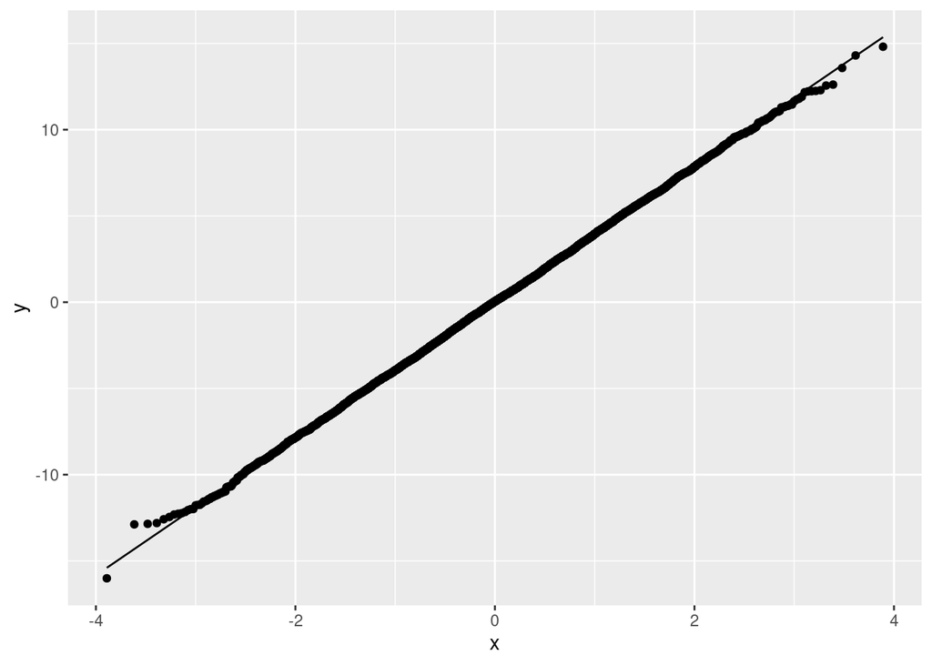

```r
ggplot(pop, aes(sample = resid(mod_pop))) + stat_qq() + stat_qq_line()
```

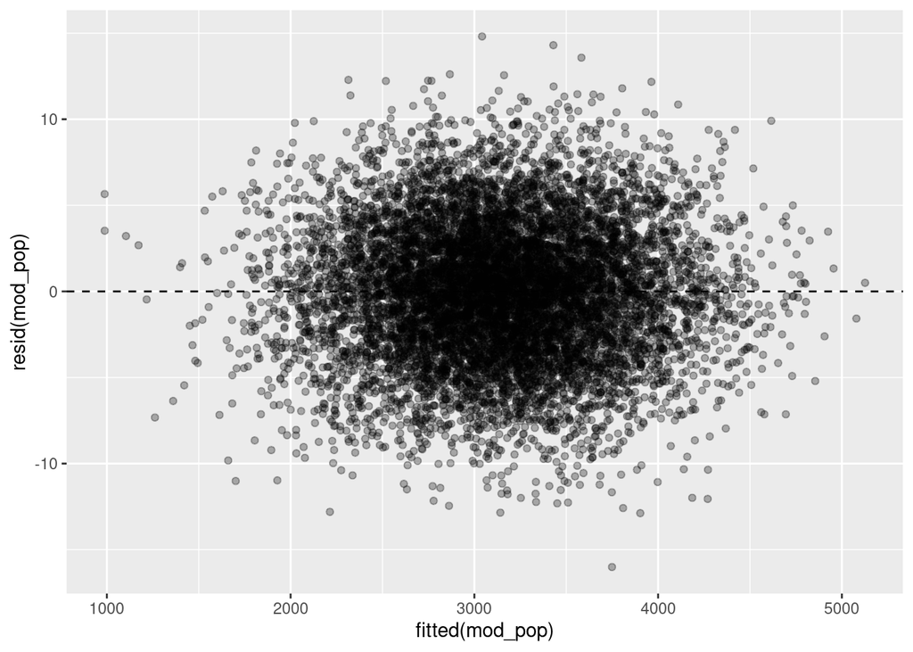

```r
ggplot(pop, aes(x = fitted(mod_pop), y = resid(mod_pop))) +
  geom_point(alpha = .3) + geom_hline(yintercept = 0, lty = 2)
```

```r
print(car::vif(mod_pop))
```

```
##         sexo escolaridade  experiencia
##     1.000450     1.000438     1.000017
```

### Explicação sobre cada comando

#### 1. Q‒Q plot dos resíduos

```r
ggplot(pop, aes(sample = resid(mod_pop))) +
  stat_qq() +                       # pontos quantil-a-quantil
  stat_qq_line()                   # linha de referência
```

- **Objetivo**: verificar se os resíduos do modelo (`resid(mod_pop)`) seguem distribuição Normal.
- **Como ler**:
  - Pontos próximos da linha ⇒ resíduos ~ Normal ⇒ boa premissa para testes-t e intervalos.
  - Desvios sistemáticos nas caudas ⇒ possível assimetria ou caudas pesadas.

#### 2. Resíduos versus valores ajustados

```r
ggplot(pop, aes(x = fitted(mod_pop), y = resid(mod_pop))) +
  geom_point(alpha = .3) +          # nuvem de pontos sem sobrecarregar
  geom_hline(yintercept = 0, lty = 2) # linha horizontal em zero
```

- **Objetivo**: checar **homocedasticidade** (variância constante do erro).
- **Como ler**:
  - Nuvem “espalhada” de forma uniforme ao redor da linha 0 ⇒ variância constante.
  - Padrão em funil ou curva ⇒ heterocedasticidade; considere erros robustos ou transformação de variáveis.

#### 3. VIF – multicolinearidade

```r
print(car::vif(mod_pop))
```

- **Função**: `vif()` (Variance Inflation Factor) do pacote **car**.
- **Resultado**: um valor para cada preditor.
  - **VIF < 5** (alguns usam <10) → correlação moderada ou baixa entre regressoras; coeficientes estáveis.
  - **VIF alto** → multicolinearidade; erros-padrão inflados e sinais instáveis.

> Em resumo:
> 1. **Q‒Q plot** avalia normalidade dos erros.
> 2. **Resíduos × ajustados** procura heterocedasticidade.
> 3. **VIF** mede multicolinearidade entre variáveis explicativas.